# Maritime Innovation Centers

Bruce Hartman

March 31, 2025

I’m starting to look at maritime innovations and entrepreneurs and how they are succeeding and getting funded now. My friend Chris Clott and I have in mind a paper on the subject.

We are looking at some data on startups, the maritime areas they are in, and how much money they’ve raised and when.

Fast forward two years and we have written and published the paper. It’s not too favorable to maritime accelerators and incubators unless they are in the software area. Funding for startups with hard products in the maritime arena is harder to come by than funding for software-based startups. We looked at startups that became unicorns, firms valued at over a billion dollars. Those are overwhelmingly in the soft category.

Startups that try to develop equipment for the maritime industry are not so attractive for venture capitalist money. They need a test bed, and therefore often need to partner with an established maritime organization — a ship owner, a port terminal, or a storage yard— and that means they are often bought up if they are successful rather than being marketed openly. Often the investments they garner have strings attached, like ownership of patents, or dedicated rights of use for a period, designed to give the sponsor a competitive advantage.

The graph below shows how soft investments tend to dominate hard investments. And our study shows that many hard investments originate in China rather than the rest of the world.

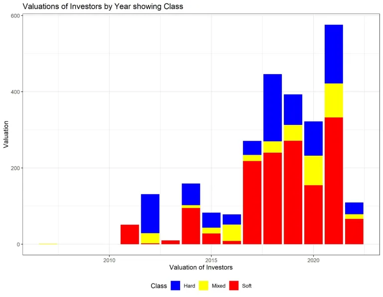